# Assignment 1: Estimating CDF and PDF

Sean Schilk

Due: 2/3/26

## **Question 1: Cumulative Distribution Function (CDF) Estimation**

The following failure times (in hours) were observed for 8 electronic components:

23, 45, 67, 89, 112, 156, 189, 245

1. Write an R function implementing the ECDF $\hat{F}_n(t)$ according to its mathematical definition. Validate your implementation using R’s ecdf() function on the given data, with comparison based on their step functions.

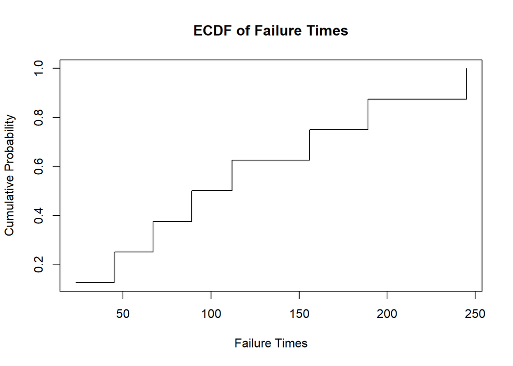

```r
#dataset
times <- c(23, 45, 67, 89, 112, 156, 189, 245)
uniq.time <- sort(unique(times))   # need to sort the data values

my.ECDF <- function(indat, outx){
  # outx - a vector of given values
  freq.table <- table(indat)                          # frequency table
  uniq <- as.numeric(names(freq.table))          # unique data values
  rep.time <- as.vector(freq.table)                   # frequencies of the unique data values
  cum.rel.feq <- cumsum(rep.time)/sum(rep.time)       # cumulative relative frequencies: CDF
  cum.prob <- NULL
  for (i in 1:length(outx)){
    intvl.id <- which(uniq <= outx[i])      # identify the index meeting the condition
    cum.prob[i] <- cum.rel.feq[max(intvl.id)] # extract the cumulative prob according to CDF
  }
  cum.prob
}

plot(uniq.time, my.ECDF(indat = times, outx = uniq.time), type = "s",
     main = "ECDF of Failure Times",
     xlab = "Failure Times",
     ylab = "Cumulative Probability")
```

## **Question 2: Density Function Estimation**

Consider the following failure times from a mechanical system:

12.3, 14.7, 15.2, 16.8, 18.1, 19.4, 20.6, 22.3, 23.9, 25.4

1. Create a histogram of the data using 3 equally spaced bins. What is the estimated density in each bin? Describe the shape of the histogram’s distribution.

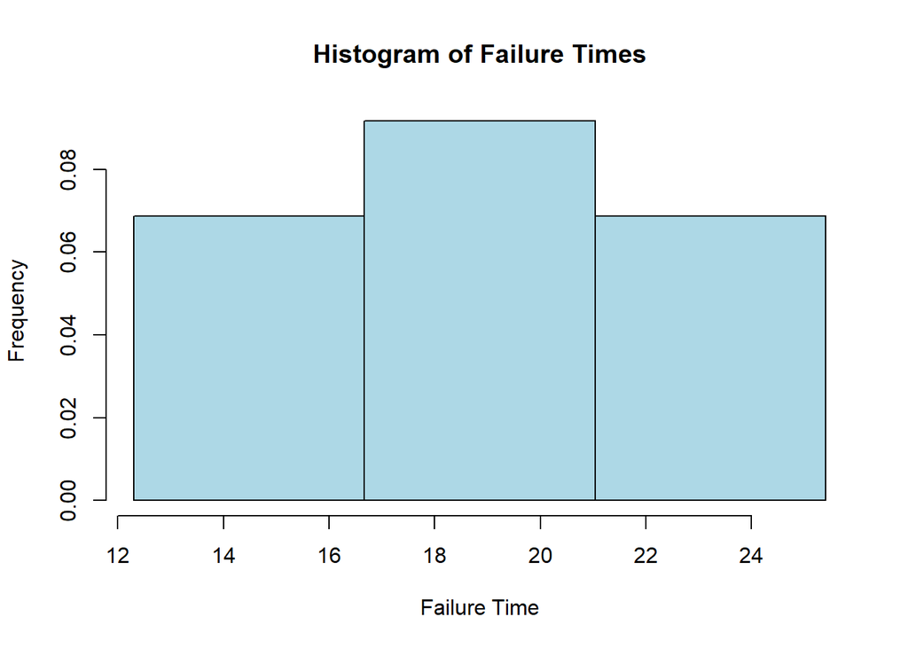

```r
x <- c(12.3, 14.7, 15.2, 16.8, 18.1, 19.4, 20.6, 22.3, 23.9, 25.4)

breaks <- seq(min(x), max(x), length.out = 4)  # 4 break points → 3 bins

hist(x, breaks = breaks, freq = FALSE, col = "lightblue",
     main = "Histogram of Failure Times",
     xlab = "Failure Time", ylab = "Frequency")
```

The estimated density of the 3 bins are as follows from left to right: .07, .09, .07. The histogram’s distribution shape follows a bell curve

2. Write an R function that computes kernel density estimates using a Gaussian kernel with $h=2$. Validate your implementation against R’s built-in density() function.

$$\hat{f}_h(t) = \frac{1}{nh}\sum_{i=1}^n K\left( \frac{t-t_i}{h}\right),
\ \ \text{ where } \ \ K(u) = \frac{1}{\sqrt{2\pi}} e^{-u^2/2}.$$

```r
# in.dat = x
# h = 2
###
my.kerf <- function(in.data, h, out.x){
  n <- length(in.data)     # sample size
  den <- NULL              # density vector to store output values
  for (i in 1:length(out.x)){
     den[i] <- sum(dnorm((out.x[i] - in.data)/h)) / (n * h)  # kernel density formula
  }
  den  # return density values based on the out.x values
}


xx = seq(0,100, length=200)
my.den <- my.kerf(in.data = times, h = 2, out.x = xx)
## density()
kde <- density(times, bw = 2, kernel = "gaussian")
```

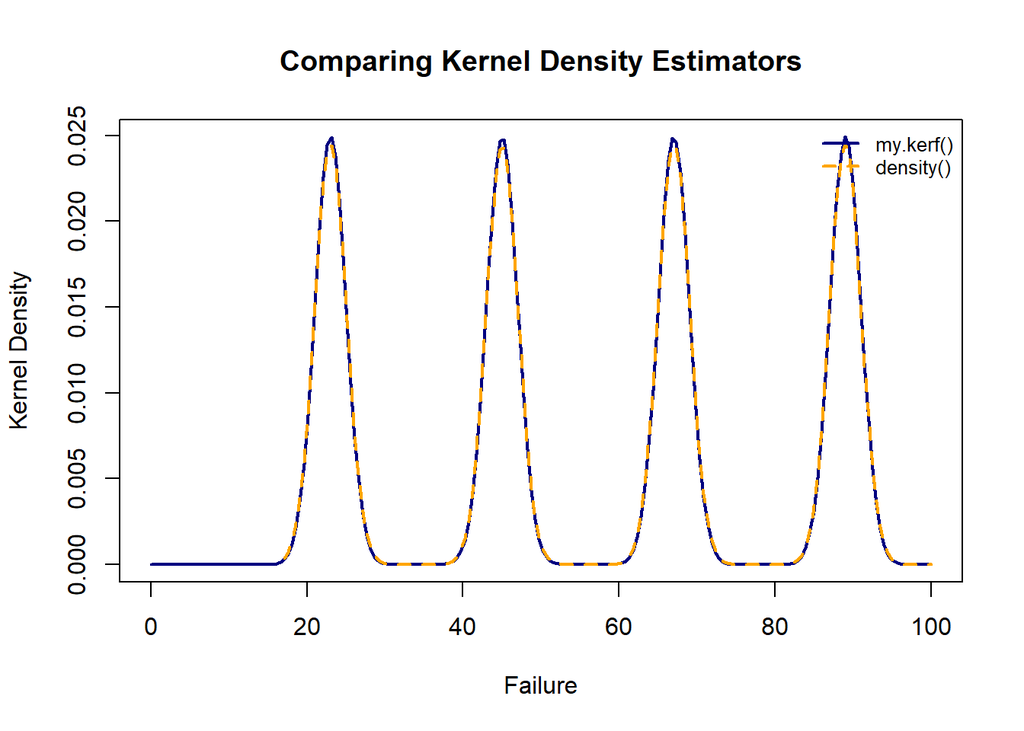

```r
kde.y <-approx(kde$x, kde$y, xout = xx)$y
## base R plot
plot(xx, my.den, type = "l", main = "Comparing Kernel Density Estimators",
     xlab = "Failure",
     ylab = "Kernel Density",
     lty = 1,
     lwd = 2,
     col = "navy")
## add density curve based on the built-in density()
lines(xx, kde.y, lty = 2, lwd = 2, col = "orange")
legend("topright", c("my.kerf()", "density()"), lty =c(1,2), lwd = rep(2,2),
       col = c("navy", "orange"), cex = 0.8, bty = "n")
```

Both functions behaved similarily, overlapping through the whole plot.

3. Write a custom R function that computes kernel density estimates using the Epanechnikov kernel with $h=2$. Validate your implementation by comparing results with R’s built-in density() function for Gaussian kernel estimation.

$$\hat{f}_h(t) = \frac{1}{nh}\sum_{i=1}^n K\left( \frac{t-t_i}{h}\right),
\ \ \text{ where } \ \ K(u) = \frac{3}{4}(1 - u^2) \ \ \text{ for } \ \
|u| \le 1.$$

```r
my.kerf.epan <- function(in.data, h, out.x){
  n <- length(in.data)
  den <- numeric(length(out.x))

  for (i in seq_along(out.x)){
    x.kernel <- (out.x[i] - in.data)/h
    epanechnikov.kernel <- ifelse(abs(x.kernel) <= 1, 0.75 * (1 - x.kernel^2), 0)
    den[i] <- sum(epanechnikov.kernel) / (n * h)
  }

  return(den)
}

xx = seq(0,100, length=200)
my.den <- my.kerf(in.data = times, h = 2, out.x = xx)
## density()
kde <- density(times, bw = 2, kernel = "epanechnikov")
```

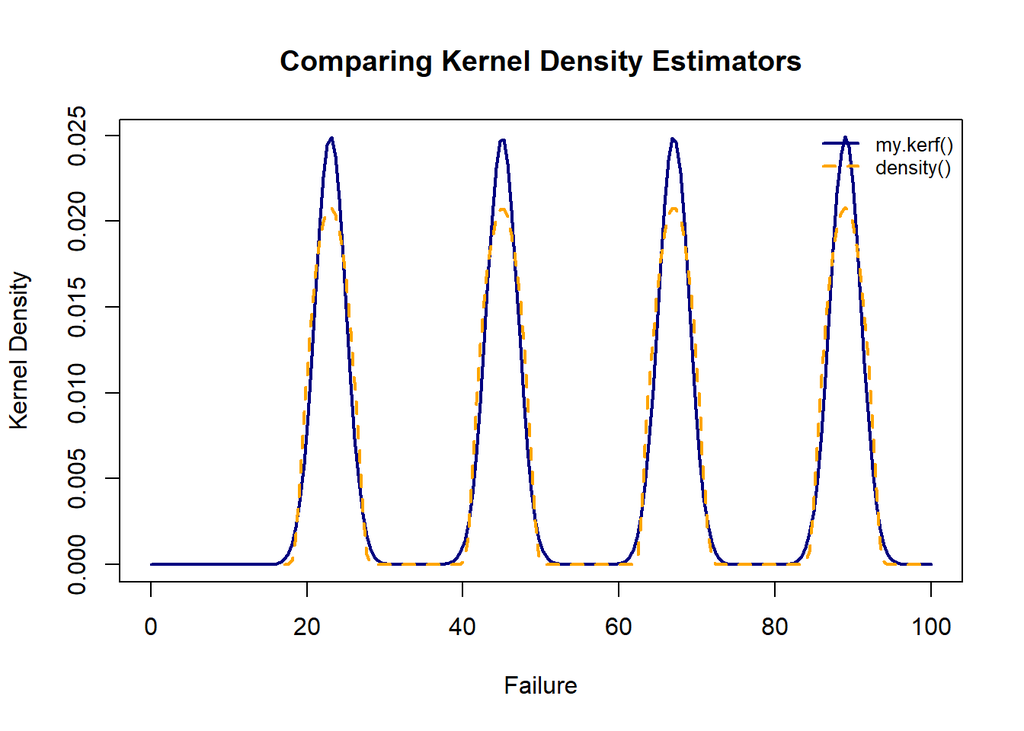

```r
kde.y <-approx(kde$x, kde$y, xout = xx)$y
## base R plot
plot(xx, my.den, type = "l", main = "Comparing Kernel Density Estimators",
     xlab = "Failure",
     ylab = "Kernel Density",
     lty = 1,
     lwd = 2,
     col = "navy")
## add density curve based on the built-in density()
lines(xx, kde.y, lty = 2, lwd = 2, col = "orange")
legend("topright", c("my.kerf()", "density()"), lty =c(1,2), lwd = rep(2,2),
       col = c("navy", "orange"), cex = 0.8, bty = "n")
```

4. How does the choice of kernel (Gaussian vs. Epanechnikov) affect the density estimate? For both kernel estimators applied to this dataset, what happens when we select $h=1.5$ versus $h=2.5$?

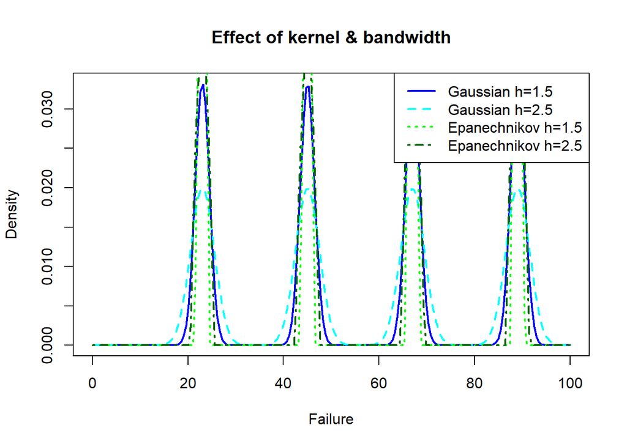

```r
h1 <- 1.5
h2 <- 2.5

# Gaussian
kde.gauss.h1 <- my.kerf(in.data = times, h = h1, out.x = xx)
kde.gauss.h2 <- my.kerf(in.data = times, h = h2, out.x = xx)

# Epanechnikov
kde.epan.h1 <- my.kerf.epan(in.data = times, h = h1, out.x = xx)
kde.epan.h2 <- my.kerf.epan(in.data = times, h = h2, out.x = xx)

plot(xx, kde.gauss.h1, type="l", col="blue", lwd=2, main="Effect of kernel & bandwidth",
     xlab="Failure", ylab="Density")
lines(xx, kde.gauss.h2, col="cyan", lwd=2, lty=2)
lines(xx, kde.epan.h1, col="green", lwd=2, lty=3)
lines(xx, kde.epan.h2, col="darkgreen", lwd=2, lty=4)
legend("topright", c("Gaussian h=1.5","Gaussian h=2.5",
                      "Epanechnikov h=1.5","Epanechnikov h=2.5"),
       col=c("blue","cyan","green","darkgreen"), lwd=2, lty=1:4)
```